# VENDOR_PERFORMANCE_ANALYSIS

```python
import pandas as pd
import numpy as np
import matplotlib.pyplot as plt
import seaborn as sns
import warnings
from scipy.stats import ttest_ind
import scipy.stats as stats
from sqlalchemy import create_engine

warnings.filterwarnings('ignore')

# ✅ Step 1: Connect to the 'postgres' default database
engine = create_engine("postgresql+psycopg2://postgres:Admin@localhost:1223/postgres")

# Connect to your demo database
engine = create_engine("postgresql+psycopg2://postgres:Admin@localhost:1223/demo")

# Query your vendor_sales table
df = pd.read_sql_query("SELECT * FROM vendor_sales;", engine)

print("✅ Data from vendor_sales table:")
```

```
✅ Data from vendor_sales table:
```

```python
df.info()
```

```
<class 'pandas.core.frame.DataFrame'>
RangeIndex: 10692 entries, 0 to 10691
Data columns (total 18 columns):
 #   Column                 Non-Null Count  Dtype
---  ------                 --------------  -----
 0   vendornumber           10692 non-null  int64
 1   vendorname             10692 non-null  object
 2   brand                  10692 non-null  object
 3   description            10692 non-null  object
 4   purchaseprice          10692 non-null  float64
 5   actualprice            10692 non-null  object
 6   volume                 10692 non-null  float64
 7   totalpurchasequantity  10692 non-null  int64
 8   totalpurchasedollars   10692 non-null  float64
 9   totalsaledollar        10692 non-null  float64
 10  totalsaleprice         10692 non-null  float64
 11  totalsalesquantity     10692 non-null  float64
 12  totalexcisetax         10692 non-null  float64
 13  freightcost            10692 non-null  float64
 14  Gross profit           10692 non-null  float64
 15  Profitmargin           10692 non-null  float64
 16  Stockturnover          10692 non-null  float64
 17  SaleToPurchaseRatio    10692 non-null  float64
dtypes: float64(12), int64(2), object(4)
memory usage: 1.5+ MB
```

```python
df.describe().T
```

|  | count | mean | std | min | 25% | 50% | 75% | max |
| --- | --- | --- | --- | --- | --- | --- | --- | --- |
| vendornumber | 10692.0 | 1.065065e+04 | 18753.519148 | 2.00 | 3951.000000 | 7153.000000 | 9552.000000 | 2.013590e+05 |
| purchaseprice | 10692.0 | 2.438530e+01 | 109.269375 | 0.36 | 6.840000 | 10.455000 | 19.482500 | 5.681810e+03 |
| volume | 10692.0 | 8.473605e+02 | 664.309212 | 50.00 | 750.000000 | 750.000000 | 750.000000 | 2.000000e+04 |
| totalpurchasequantity | 10692.0 | 3.140887e+03 | 11095.086769 | 1.00 | 36.000000 | 262.000000 | 1975.750000 | 3.376600e+05 |
| totalpurchasedollars | 10692.0 | 3.010669e+04 | 123067.799627 | 0.71 | 453.457500 | 3655.465000 | 20738.245000 | 3.811252e+06 |
| totalsaledollar | 10692.0 | 4.223907e+04 | 167655.265984 | 0.00 | 729.220000 | 5298.045000 | 28396.915000 | 5.101920e+06 |
| totalsaleprice | 10692.0 | 1.879378e+04 | 44952.773386 | 0.00 | 289.710000 | 2857.800000 | 16059.562500 | 6.728193e+05 |
| totalsalesquantity | 10692.0 | 3.077482e+03 | 10952.851391 | 0.00 | 33.000000 | 261.000000 | 1929.250000 | 3.349390e+05 |
| totalexcisetax | 10692.0 | 1.774226e+03 | 10975.582240 | 0.00 | 4.800000 | 46.570000 | 418.650000 | 3.682428e+05 |
| freightcost | 10692.0 | 6.143376e+04 | 60938.458032 | 0.09 | 14069.870000 | 50293.620000 | 79528.990000 | 2.570321e+05 |
| Gross profit | 10692.0 | 1.213238e+04 | 46224.337964 | -52002.78 | 52.920000 | 1399.640000 | 8660.200000 | 1.290668e+06 |
| Profitmargin | 10692.0 | -inf | NaN | -inf | 13.324515 | 30.405457 | 39.956135 | 9.971666e+01 |
| Stockturnover | 10692.0 | 1.706793e+00 | 6.020460 | 0.00 | 0.807229 | 0.981529 | 1.039342 | 2.745000e+02 |
| SaleToPurchaseRatio | 10692.0 | 2.504390e+00 | 8.459067 | 0.00 | 1.153729 | 1.436894 | 1.665449 | 3.529286e+02 |

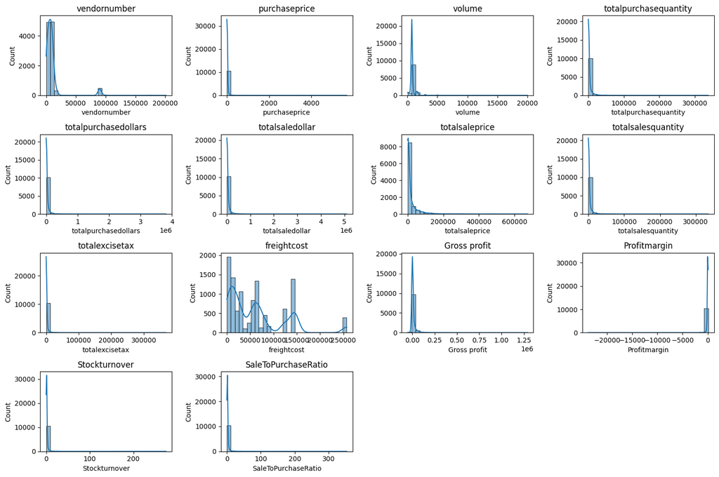

```python
# Distribution plots for numericals
numericals_cols = df.select_dtypes(include=np.number).columns

plt.figure(figsize=(15, 10))
for i, col in enumerate(numericals_cols):
    plt.subplot(4, 4,i+1)
    sns.histplot(df[col], kde=True, bins=30)
    plt.title(col)
plt.tight_layout()
plt.show()
```

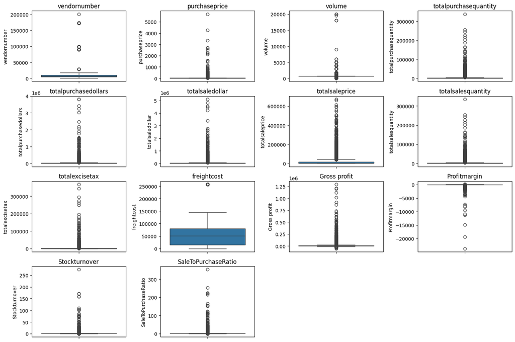

```python
# Outlier detection with boxplot
plt.figure(figsize=(15, 10))
for i, col in enumerate(numericals_cols):
    plt.subplot(4, 4, i+1)
    sns.boxplot(y=df[col])
    plt.title(col)
plt.tight_layout()
plt.show()
```

```python
pd.read_sql_query("select * from vendor_sales limit 0", engine)
```

|  | vendornumber | vendorname | brand | description | purchaseprice | actualprice | volume | totalpurchasequantity | totalpurchasedollars | totalsaledollar | totalsaleprice | totalsalesquantity | totalexcisetax | freightcost | Gross profit | Profitmargin | Stockturnover | SaleToPurchaseRatio |
| --- | --- | --- | --- | --- | --- | --- | --- | --- | --- | --- | --- | --- | --- | --- | --- | --- | --- | --- |

```python
df.columns
```

```
Index(['vendornumber', 'vendorname', 'brand', 'description', 'purchaseprice',
       'actualprice', 'volume', 'totalpurchasequantity',
       'totalpurchasedollars', 'totalsaledollar', 'totalsaleprice',
       'totalsalesquantity', 'totalexcisetax', 'freightcost', 'Gross profit',
       'Profitmargin', 'Stockturnover', 'SaleToPurchaseRatio'],
      dtype='object')
```

```python
#  Lets filter the data removing  inconsistencies
query = """
SELECT *
FROM vendor_sales
WHERE "Gross profit" > 0
  AND "Profitmargin" > 0
  AND totalsalesquantity > 0
"""
df = pd.read_sql_query(query, engine)
df.head(5)
```

|  | vendornumber | vendorname | brand | description | purchaseprice | actualprice | volume | totalpurchasequantity | totalpurchasedollars | totalsaledollar | totalsaleprice | totalsalesquantity | totalexcisetax | freightcost | Gross profit | Profitmargin | Stockturnover | SaleToPurchaseRatio |
| --- | --- | --- | --- | --- | --- | --- | --- | --- | --- | --- | --- | --- | --- | --- | --- | --- | --- | --- |
| 0 | 1128 | BROWN-FORMAN CORP | 1233 | Jack Daniels No 7 Black | 26.27 | 36.99 | 1750.0 | 145080 | 3811251.60 | 5101919.51 | 672819.31 | 142049.0 | 260999.20 | 68601.68 | 1290667.91 | 25.297693 | 0.979108 | 1.338647 |
| 1 | 4425 | MARTIGNETTI COMPANIES | 3405 | Tito's Handmade Vodka | 23.19 | 28.99 | 1750.0 | 164038 | 3804041.22 | 4819073.49 | 561512.37 | 160247.0 | 294438.66 | 144929.24 | 1015032.27 | 21.062810 | 0.976890 | 1.266830 |
| 2 | 17035 | PERNOD RICARD USA | 8068 | Absolut 80 Proof | 18.24 | 24.99 | 1750.0 | 187407 | 3418303.68 | 4538120.60 | 461140.15 | 187140.0 | 343854.07 | 123780.22 | 1119816.92 | 24.675786 | 0.998575 | 1.327594 |
| 3 | 3960 | DIAGEO NORTH AMERICA INC | 4261 | Capt Morgan Spiced Rum | 16.17 | 22.99 | 1750.0 | 201682 | 3261197.94 | 4475972.88 | 420050.01 | 200412.0 | 368242.80 | 257032.07 | 1214774.94 | 27.139908 | 0.993703 | 1.372493 |
| 4 | 3960 | DIAGEO NORTH AMERICA INC | 3545 | Ketel One Vodka | 21.89 | 29.99 | 1750.0 | 138109 | 3023206.01 | 4223107.62 | 545778.28 | 135838.0 | 249587.83 | 257032.07 | 1199901.61 | 28.412764 | 0.983556 | 1.396897 |

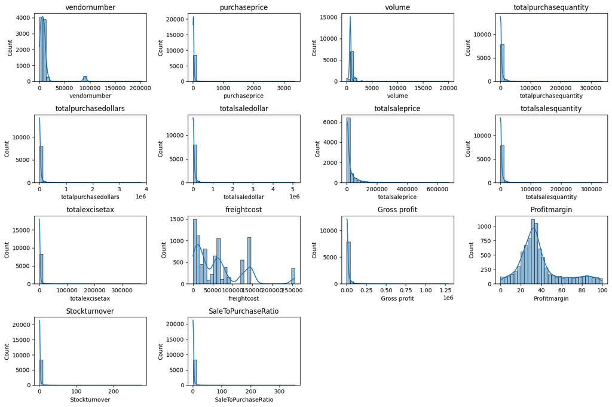

```python
# Distribution plots for numericals
numericals_cols = df.select_dtypes(include=np.number).columns

plt.figure(figsize=(15, 10))
for i, col in enumerate(numericals_cols):
    plt.subplot(4, 4,i+1)
    sns.histplot(df[col], kde=True, bins=30)
    plt.title(col)
plt.tight_layout()
plt.show()
```

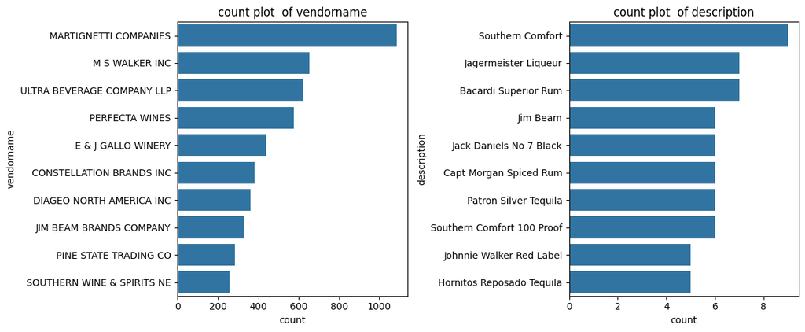

```python
# Count plot on categorical colums
categorical_colums= ['vendorname','description']

plt.figure(figsize=(12, 5))
for i, col in enumerate(categorical_colums):
    plt.subplot(1, 2, i+1)
    sns.countplot(y=df[col], order=df[col].value_counts().index[:10])
    plt.title(f"count plot  of {col}")
plt.tight_layout()
plt.show()
```

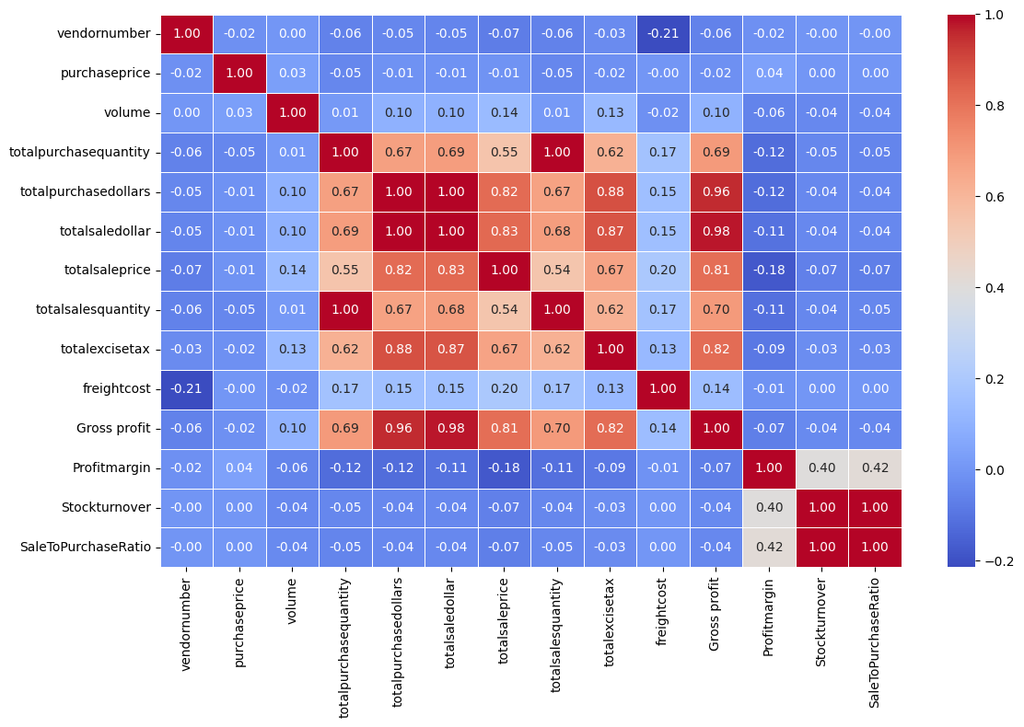

```python
#  correlationn heat map
plt.figure(figsize=(12,8))
correlation_matrix = df[numericals_cols].corr()
sns.heatmap(correlation_matrix, annot=True, fmt=".2f", cmap="coolwarm", linewidths=0.5)
plt.tight_layout()
plt.show()
```

```python
brand_performance = df.groupby('description').agg({
    'totalsaledollar':'sum',
    'Profitmargin':'mean'}).reset_index()
brand_performance
```

|  | description | totalsaledollar | Profitmargin |
| --- | --- | --- | --- |
| 0 | (RI) 1 | 21519.09 | 18.060661 |
| 1 | .nparalleled Svgn Blanc | 1094.63 | 29.978166 |
| 2 | 10 Span Cab Svgn CC | 2703.89 | 20.937612 |
| 3 | 10 Span Chard CC | 3325.56 | 27.806445 |
| 4 | 10 Span Pnt Gris Monterey Cy | 2082.22 | 32.226182 |
| ... | ... | ... | ... |
| 7702 | Zorvino Vyds Sangiovese | 10579.03 | 29.525675 |
| 7703 | Zuccardi Q Malbec | 1639.18 | 23.981503 |
| 7704 | Zum Rsl | 10857.34 | 32.675038 |
| 7705 | Zwack Liqueur | 227.88 | 16.653502 |
| 7706 | von Buhl Jazz Rsl | 1359.11 | 90.773374 |

7707 rows × 3 columns

```python
low_sales_thresold = brand_performance['totalsaledollar'].quantile(0.15)
high_sales_thrsold = brand_performance['Profitmargin'].quantile(0.85)
```

```python
low_sales_thresold
```

```
np.float64(560.299)
```

```python
high_sales_thrsold
```

```
np.float64(64.97017552750113)
```

```python
target_brands = brand_performance[
    (brand_performance['totalsaledollar'] <= low_sales_thresold) &
    (brand_performance['Profitmargin'] >= high_sales_thrsold)
]
print("Brands with low sales but high  profit margin:")
display(target_brands.sort_values('totalsaledollar'))
```

```
Brands with low sales but high  profit margin:
```

|  | description | totalsaledollar | Profitmargin |
| --- | --- | --- | --- |
| 6199 | Santa Rita Organic Svgn Bl | 9.99 | 66.466466 |
| 2369 | Debauchery Pnt Nr | 11.58 | 65.975820 |
| 2070 | Concannon Glen Ellen Wh Zin | 15.95 | 83.448276 |
| 2188 | Crown Royal Apple | 27.86 | 89.806174 |
| 6237 | Sauza Sprklg Wild Berry Marg | 27.96 | 82.153076 |
| ... | ... | ... | ... |
| 5074 | Nanbu Bijin Southern Beauty | 535.68 | 76.747312 |
| 2271 | Dad's Hat Rye Whiskey | 538.89 | 81.851584 |
| 57 | A Bichot Clos Marechaudes | 539.94 | 67.740860 |
| 6245 | Sbragia Home Ranch Merlot | 549.75 | 66.444748 |
| 3326 | Goulee Cos d'Estournel 10 | 558.87 | 69.434752 |

198 rows × 3 columns

```python
brands_perf=brand_performance[brand_performance['totalsaledollar']<10000]
```

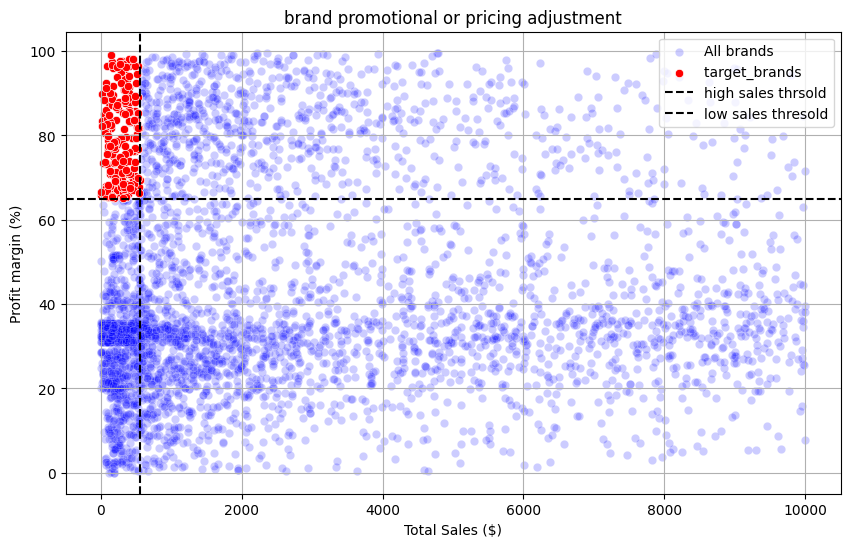

```python
plt.figure(figsize=(10,6))
sns.scatterplot(data=brands_perf, x="totalsaledollar", y="Profitmargin", color="blue", label="All brands", alpha =0.2)
sns.scatterplot(data=target_brands, x="totalsaledollar",y="Profitmargin", color="red", label="target_brands ")

plt.axhline(high_sales_thrsold, linestyle='--', color='black', label="high sales thrsold")
plt.axvline(low_sales_thresold, linestyle='--', color='black', label="low sales thresold")

plt.xlabel("Total Sales ($)")
plt.ylabel("Profit margin (%)")
plt.title("brand promotional or pricing adjustment")
plt.legend()
plt.grid(True)
plt.show()
```

which vendors and brands demonstrates the higest saeles performance

```python
def format_dollars(value):
    if value >= 1_000_000:
        return f"{value / 1_000_000:.2f}M"
    elif value >= 1_000:
        return f"{value / 1_000:.2f}K"
    else:
        return str(value)
```

```python
top_Vendors = df.groupby('vendorname')['totalsaledollar'].sum().nlargest(10)
top_brands = df.groupby('description')['totalsaledollar'].sum().nlargest(10)
```

```python
top_brands.apply(lambda x : format_dollars(x))
```

```
description
Jack Daniels No 7 Black    7.96M
Tito's Handmade Vodka      7.40M
Grey Goose Vodka           7.21M
Capt Morgan Spiced Rum     6.36M
Absolut 80 Proof           6.24M
Jameson Irish Whiskey      5.72M
Ketel One Vodka            5.07M
Baileys Irish Cream        4.15M
Kahlua                     3.60M
Tanqueray                  3.46M
Name: totalsaledollar, dtype: object
```

```python
top_Vendors.apply(lambda x : format_dollars(x))
```

```
vendorname
DIAGEO NORTH AMERICA INC      67.99M
MARTIGNETTI COMPANIES         39.33M
PERNOD RICARD USA             32.06M
JIM BEAM BRANDS COMPANY       31.42M
BACARDI USA INC               24.85M
CONSTELLATION BRANDS INC      24.22M
E & J GALLO WINERY            18.40M
BROWN-FORMAN CORP             18.25M
ULTRA BEVERAGE COMPANY LLP    16.50M
M S WALKER INC                14.71M
Name: totalsaledollar, dtype: object
```

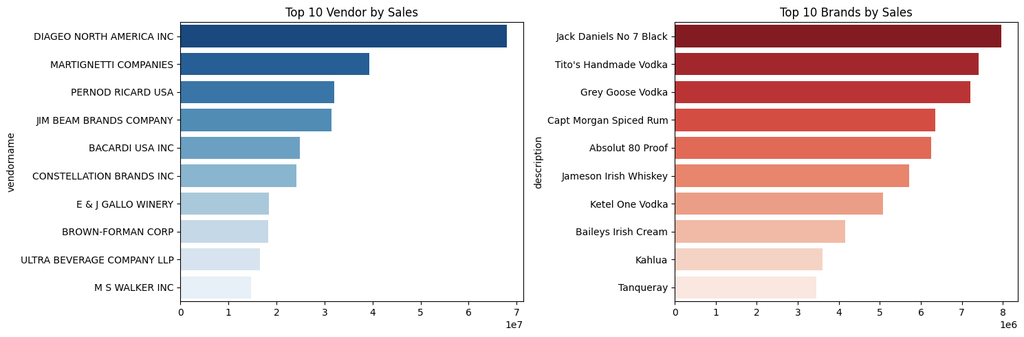

```python
plt.figure(figsize=(15, 5))

# Plot For top vendors
plt.subplot(1, 2, 1)
ax1= sns.barplot(y=top_Vendors.index, x=top_Vendors.values, palette="Blues_r")
plt.title("Top 10 Vendor by Sales")

# plot for tops brands
plt.subplot(1, 2, 2)
ax2= sns.barplot(y=top_brands.index, x=top_brands.values, palette="Reds_r")
plt.title("Top 10 Brands by Sales")

plt.tight_layout()
plt.show()
```

# which vendor contribute the most to total purchase dollars?

```python
vendor_Performance = df.groupby('vendorname'). agg({
    'totalpurchasedollars':sum,
    'Gross profit':sum,
    'totalsaledollar':sum
}).reset_index()
```

```python
vendor_Performance['PurchaseContribution%']= vendor_Performance['totalpurchasedollars'] /vendor_Performance['totalpurchasedollars'].sum() * 100
```

```python
vendor_Performance = round(vendor_Performance.sort_values(by='PurchaseContribution%', ascending= False),2)
```

```python
top_Vendors = vendor_Performance.head(10)
top_Vendors['totalpurchasedollars'] = top_Vendors['totalpurchasedollars'].apply(format_dollars)
top_Vendors['Gross profit'] = top_Vendors['Gross profit'].apply(format_dollars)
top_Vendors['totalsaledollar'] = top_Vendors['totalsaledollar'].apply(format_dollars)
top_Vendors
```

|  | vendorname | totalpurchasedollars | Gross profit | totalsaledollar | PurchaseContribution% |
| --- | --- | --- | --- | --- | --- |
| 25 | DIAGEO NORTH AMERICA INC | 50.10M | 17.89M | 67.99M | 16.30 |
| 57 | MARTIGNETTI COMPANIES | 25.50M | 13.83M | 39.33M | 8.30 |
| 68 | PERNOD RICARD USA | 23.85M | 8.21M | 32.06M | 7.76 |
| 46 | JIM BEAM BRANDS COMPANY | 23.49M | 7.93M | 31.42M | 7.64 |
| 6 | BACARDI USA INC | 17.43M | 7.42M | 24.85M | 5.67 |
| 20 | CONSTELLATION BRANDS INC | 15.27M | 8.95M | 24.22M | 4.97 |
| 11 | BROWN-FORMAN CORP | 13.24M | 5.01M | 18.25M | 4.31 |
| 30 | E & J GALLO WINERY | 12.07M | 6.33M | 18.40M | 3.93 |
| 106 | ULTRA BEVERAGE COMPANY LLP | 11.17M | 5.34M | 16.50M | 3.63 |
| 53 | M S WALKER INC | 9.76M | 4.94M | 14.71M | 3.18 |

```python
top_Vendors['PurchaseContribution%'].sum()
```

```
np.float64(65.69000000000001)
```

```python
top_Vendors['Cumalative_Contribution%'] = top_Vendors['PurchaseContribution%'].cumsum()
top_Vendors
```

|  | vendorname | totalpurchasedollars | Gross profit | totalsaledollar | PurchaseContribution% | Cumalative_Contribution% |
| --- | --- | --- | --- | --- | --- | --- |
| 25 | DIAGEO NORTH AMERICA INC | 50.10M | 17.89M | 67.99M | 16.30 | 16.30 |
| 57 | MARTIGNETTI COMPANIES | 25.50M | 13.83M | 39.33M | 8.30 | 24.60 |
| 68 | PERNOD RICARD USA | 23.85M | 8.21M | 32.06M | 7.76 | 32.36 |
| 46 | JIM BEAM BRANDS COMPANY | 23.49M | 7.93M | 31.42M | 7.64 | 40.00 |
| 6 | BACARDI USA INC | 17.43M | 7.42M | 24.85M | 5.67 | 45.67 |
| 20 | CONSTELLATION BRANDS INC | 15.27M | 8.95M | 24.22M | 4.97 | 50.64 |
| 11 | BROWN-FORMAN CORP | 13.24M | 5.01M | 18.25M | 4.31 | 54.95 |
| 30 | E & J GALLO WINERY | 12.07M | 6.33M | 18.40M | 3.93 | 58.88 |
| 106 | ULTRA BEVERAGE COMPANY LLP | 11.17M | 5.34M | 16.50M | 3.63 | 62.51 |
| 53 | M S WALKER INC | 9.76M | 4.94M | 14.71M | 3.18 | 65.69 |

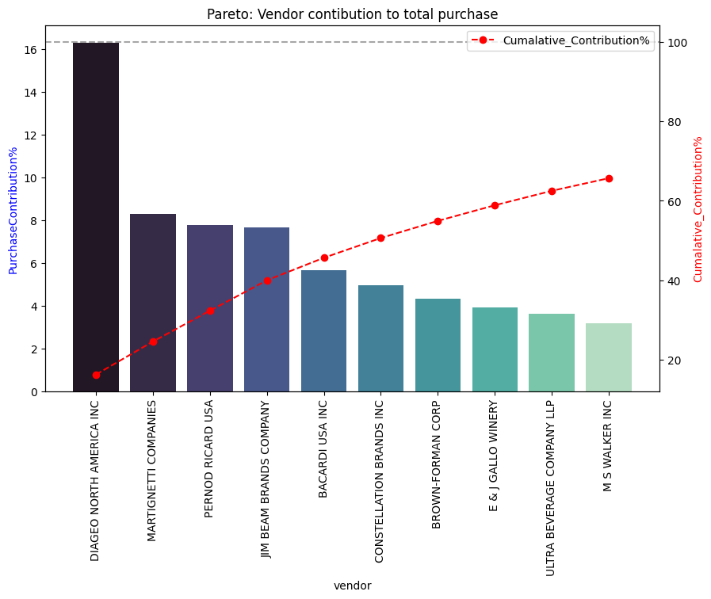

```python
fig, ax1 = plt.subplots(figsize=(10, 6))
#  Bar plot for purchase contribution
sns.barplot(x=top_Vendors['vendorname'], y=top_Vendors['PurchaseContribution%'], palette='mako', ax=ax1)


ax2 = ax1.twinx()
ax2.plot(top_Vendors['vendorname'], top_Vendors['Cumalative_Contribution%'], color='red', marker='o',linestyle='dashed', label='Cumalative_Contribution%')

ax1.set_xticklabels(top_Vendors['vendorname'], rotation=90)
ax1.set_ylabel('PurchaseContribution%', color='blue')
ax2.set_ylabel('Cumalative_Contribution%', color='red')
ax1.set_xlabel('vendor')
ax1.set_title('Pareto: Vendor contibution to total purchase')

ax2.axhline(y=100,color='gray', linestyle='dashed', alpha=0.7)
ax2.legend(loc='upper right')

plt.show()
```

How much total procurement is depentdent on the top vendors?

```python
print(f"Total Purcahse Contibution of Top 10 Vendors is {round(top_Vendors['PurchaseContribution%'].sum(), 2)}%")
```

```
Total Purcahse Contibution of Top 10 Vendors is 65.69%
```

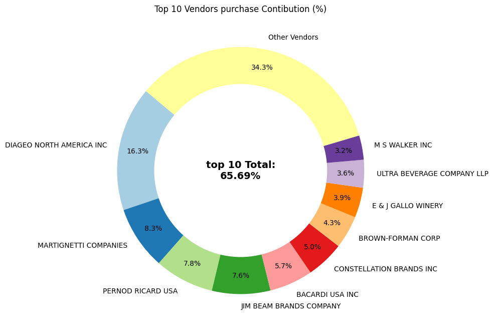

```python
vendors = list(top_Vendors['vendorname'].values)
purchase_contribution =list(top_Vendors['PurchaseContribution%'].values)
total_contribution =sum(purchase_contribution)
remaning_contibution = 100 - total_contribution

# Appends "Other Vendors" categorry
vendors.append("Other Vendors")
purchase_contribution.append(remaning_contibution)

# Donnut Chart
fig, ax = plt.subplots(figsize=(8, 8))
wedges, texts, autotexts = ax.pie(purchase_contribution, labels=vendors, autopct='%1.1f%%',
                                  startangle=140, pctdistance=0.85, colors=plt.cm.Paired.colors)

# Draw a white circle in the middle to turn it into a donut
centre_circle = plt.Circle((0, 0), 0.70, fc='white')
fig.gca().add_artist(centre_circle)

# Add Total Contribution annoation in centre
plt.text(0,0, f"top 10 Total:\n{total_contribution:.2f}%", fontsize=14, fontweight='bold', ha='center', va='center')


plt.title("Top 10 Vendors purchase Contibution (%)")
plt.show()
```

does purcahseing in bulk reducing the unit price, and what is the optimal purchase volume of cost saving

```python
df.head(2)
```

|  | vendornumber | vendorname | brand | description | purchaseprice | actualprice | volume | totalpurchasequantity | totalpurchasedollars | totalsaledollar | totalsaleprice | totalsalesquantity | totalexcisetax | freightcost | Gross profit | Profitmargin | Stockturnover | SaleToPurchaseRatio |
| --- | --- | --- | --- | --- | --- | --- | --- | --- | --- | --- | --- | --- | --- | --- | --- | --- | --- | --- |
| 0 | 1128 | BROWN-FORMAN CORP | 1233 | Jack Daniels No 7 Black | 26.27 | 36.99 | 1750.0 | 145080 | 3811251.60 | 5101919.51 | 672819.31 | 142049.0 | 260999.20 | 68601.68 | 1290667.91 | 25.297693 | 0.979108 | 1.338647 |
| 1 | 4425 | MARTIGNETTI COMPANIES | 3405 | Tito's Handmade Vodka | 23.19 | 28.99 | 1750.0 | 164038 | 3804041.22 | 4819073.49 | 561512.37 | 160247.0 | 294438.66 | 144929.24 | 1015032.27 | 21.062810 | 0.976890 | 1.266830 |

```python
df['unitpurchaseprice'] = df['totalpurchasedollars'] / df['totalpurchasequantity']
```

```python
df['Ordersize'] = pd.qcut(df['totalpurchasequantity'], q=3, labels=['Small','medium','large'] )
```

```python
df[['Ordersize','totalpurchasequantity']]
```

|  | Ordersize | totalpurchasequantity |
| --- | --- | --- |
| 0 | large | 145080 |
| 1 | large | 164038 |
| 2 | large | 187407 |
| 3 | large | 201682 |
| 4 | large | 138109 |
| ... | ... | ... |
| 8559 | Small | 2 |
| 8560 | Small | 6 |
| 8561 | Small | 2 |
| 8562 | Small | 1 |
| 8563 | Small | 1 |

8564 rows × 2 columns

```python
df.groupby('Ordersize')[['unitpurchaseprice']].mean()
```

| Ordersize | unitpurchaseprice |
| --- | --- |
| Small | 39.068186 |
| medium | 15.486414 |
| large | 10.777625 |

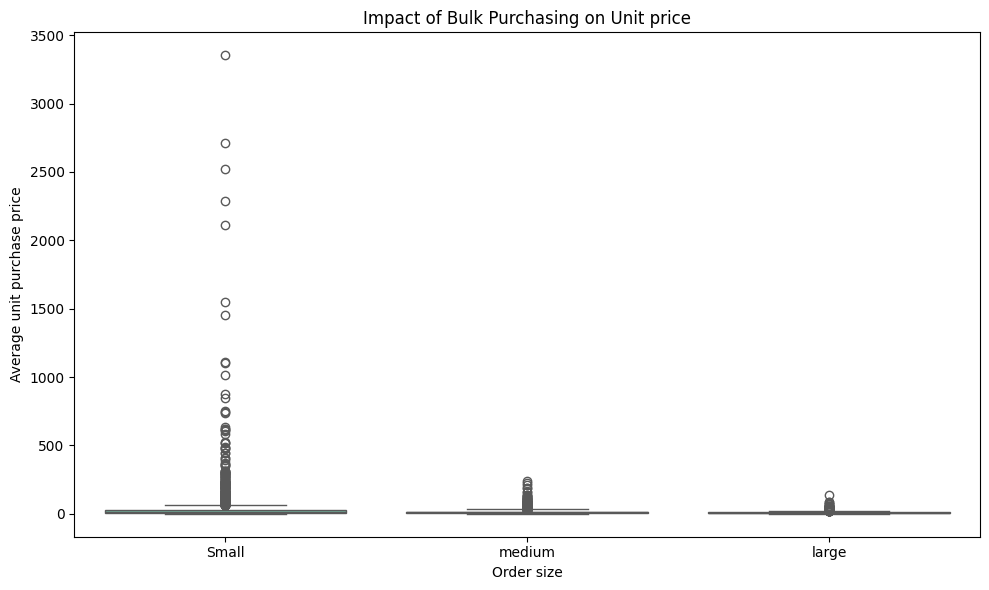

```python
plt.figure(figsize=(10, 6))
sns.boxplot(data=df, x="Ordersize", y="unitpurchaseprice", palette="Set2")
plt.title("Impact of Bulk Purchasing on Unit price")
plt.xlabel("Order size")
plt.ylabel("Average unit purchase price")
plt.tight_layout()
plt.show()
```

• Vendors buying in bulk (Large Order Size) get the lowest unit price ($10.78 per unit), meaning higher margins if they can manage inventory efficiently.

• The price difference between Small and Large orders is substantial (~72% reduction in unit cost).

• This suggests that bulk pricing strategies successfully encourage vendors to purchase in larger volumes, leading to higher overall sales despite lower per-unit revenue.

which vendor have low inventory , indicating excess stock and slow-moving product

```python
df[df['Stockturnover'] < 1].groupby('vendorname')['Stockturnover'].mean().sort_values(ascending=True)
```

```
vendorname
ALISA CARR BEVERAGES           0.615385
HIGHLAND WINE MERCHANTS LLC    0.708333
PARK STREET IMPORTS LLC        0.751306
Circa Wines                    0.755676
Dunn Wine Brokers              0.766022
                                 ...
DISARONNO INTERNATIONAL LLC    0.975577
PREMIUM PORT WINES, INC.       0.976077
TY KU LLC                      0.976982
PHILLIPS PRODUCTS CO.          0.980848
TAKARA SAKE USA INC            0.984105
Name: Stockturnover, Length: 107, dtype: float64
```

how much capital is locked unsold inventory sold as per vendor, and which vendor contibute the most it?

```python
df['Unsoldinventoryvalue'] = (df['totalpurchasequantity'] - df['totalsalesquantity']) * df['purchaseprice']
print("total unsold capital:", format_dollars(df['Unsoldinventoryvalue'].sum()))
```

```
total unsold capital: 2.71M
```

```python
# Aggregate capital  lockedd  per vendor
inventory_value_vendors = df.groupby("vendorname")['Unsoldinventoryvalue'].sum().reset_index()

# sort Vendors with higest locked capital
inventory_value_vendors = inventory_value_vendors.sort_values(by="Unsoldinventoryvalue", ascending=False)
inventory_value_vendors['Unsoldinventoryvalue'] = inventory_value_vendors['Unsoldinventoryvalue'].apply(format_dollars)
inventory_value_vendors.head(10)
```

|  | vendorname | Unsoldinventoryvalue |
| --- | --- | --- |
| 25 | DIAGEO NORTH AMERICA INC | 722.21K |
| 46 | JIM BEAM BRANDS COMPANY | 554.67K |
| 68 | PERNOD RICARD USA | 470.63K |
| 116 | WILLIAM GRANT & SONS INC | 401.96K |
| 30 | E & J GALLO WINERY | 228.28K |
| 79 | SAZERAC CO INC | 198.44K |
| 11 | BROWN-FORMAN CORP | 177.73K |
| 20 | CONSTELLATION BRANDS INC | 133.62K |
| 61 | MOET HENNESSY USA INC | 126.48K |
| 77 | REMY COINTREAU USA INC | 118.60K |

What is the 95% confidence intervals for profits margin of top-performing and low-performing vendors

```python
top_threshold = df['totalsaledollar'].quantile(0.75)
low_threshold = df['totalsaledollar'].quantile(0.25)
```

```python
top_vendors = df[df['totalsaledollar']>= top_threshold] ['Profitmargin'].dropna()
low_vendors = df[df['totalpurchasedollars']<= low_threshold]["Profitmargin"].dropna()
```

```python
top_vendors
```

```
0       25.297693
1       21.062810
2       24.675786
3       27.139908
4       28.412764
          ...
3523    79.684817
3681    85.782102
4751    93.085860
4920    95.012530
5050    94.271857
Name: Profitmargin, Length: 2141, dtype: float64
```

```python
df
```

|  | vendornumber | vendorname | brand | description | purchaseprice | actualprice | volume | totalpurchasequantity | totalpurchasedollars | totalsaledollar | ... | totalsalesquantity | totalexcisetax | freightcost | Gross profit | Profitmargin | Stockturnover | SaleToPurchaseRatio | unitpurchaseprice | Ordersize | Unsoldinventoryvalue |
| --- | --- | --- | --- | --- | --- | --- | --- | --- | --- | --- | --- | --- | --- | --- | --- | --- | --- | --- | --- | --- | --- |
| 0 | 1128 | BROWN-FORMAN CORP | 1233 | Jack Daniels No 7 Black | 26.27 | 36.99 | 1750.0 | 145080 | 3811251.60 | 5101919.51 | ... | 142049.0 | 260999.20 | 68601.68 | 1290667.91 | 25.297693 | 0.979108 | 1.338647 | 26.27 | large | 79624.37 |
| 1 | 4425 | MARTIGNETTI COMPANIES | 3405 | Tito's Handmade Vodka | 23.19 | 28.99 | 1750.0 | 164038 | 3804041.22 | 4819073.49 | ... | 160247.0 | 294438.66 | 144929.24 | 1015032.27 | 21.062810 | 0.976890 | 1.266830 | 23.19 | large | 87913.29 |
| 2 | 17035 | PERNOD RICARD USA | 8068 | Absolut 80 Proof | 18.24 | 24.99 | 1750.0 | 187407 | 3418303.68 | 4538120.60 | ... | 187140.0 | 343854.07 | 123780.22 | 1119816.92 | 24.675786 | 0.998575 | 1.327594 | 18.24 | large | 4870.08 |
| 3 | 3960 | DIAGEO NORTH AMERICA INC | 4261 | Capt Morgan Spiced Rum | 16.17 | 22.99 | 1750.0 | 201682 | 3261197.94 | 4475972.88 | ... | 200412.0 | 368242.80 | 257032.07 | 1214774.94 | 27.139908 | 0.993703 | 1.372493 | 16.17 | large | 20535.90 |
| 4 | 3960 | DIAGEO NORTH AMERICA INC | 3545 | Ketel One Vodka | 21.89 | 29.99 | 1750.0 | 138109 | 3023206.01 | 4223107.62 | ... | 135838.0 | 249587.83 | 257032.07 | 1199901.61 | 28.412764 | 0.983556 | 1.396897 | 21.89 | large | 49712.19 |
| ... | ... | ... | ... | ... | ... | ... | ... | ... | ... | ... | ... | ... | ... | ... | ... | ... | ... | ... | ... | ... | ... |
| 8559 | 9815 | WINE GROUP INC | 8527 | Concannon Glen Ellen Wh Zin | 1.32 | 4.99 | 750.0 | 2 | 2.64 | 15.95 | ... | 5.0 | 0.55 | 27100.41 | 13.31 | 83.448276 | 2.500000 | 6.041667 | 1.32 | Small | -3.96 |
| 8560 | 8004 | SAZERAC CO INC | 5683 | Dr McGillicuddy's Apple Pie | 0.39 | 0.49 | 50.0 | 6 | 2.34 | 65.66 | ... | 134.0 | 7.04 | 50293.62 | 63.32 | 96.436186 | 22.333333 | 28.059829 | 0.39 | Small | -49.92 |
| 8561 | 3924 | HEAVEN HILL DISTILLERIES | 9123 | Deep Eddy Vodka | 0.74 | 0.99 | 50.0 | 2 | 1.48 | 1.98 | ... | 2.0 | 0.10 | 14069.87 | 0.50 | 25.252525 | 1.000000 | 1.337838 | 0.74 | Small | 0.00 |
| 8562 | 3960 | DIAGEO NORTH AMERICA INC | 6127 | The Club Strawbry Margarita | 1.47 | 1.99 | 200.0 | 1 | 1.47 | 143.28 | ... | 72.0 | 15.12 | 257032.07 | 141.81 | 98.974037 | 72.000000 | 97.469388 | 1.47 | Small | -104.37 |
| 8563 | 7245 | PROXIMO SPIRITS INC. | 3065 | Three Olives Grape Vodka | 0.71 | 0.99 | 50.0 | 1 | 0.71 | 85.14 | ... | 86.0 | 4.46 | 38994.78 | 84.43 | 99.166079 | 86.000000 | 119.915493 | 0.71 | Small | -60.35 |

8564 rows × 21 columns

```python
def confidence_interval(data, confidence=0.95):
    data = np.array(data)

    # Handle empty input to avoid errors
    if len(data) == 0:
        return np.nan, np.nan, np.nan

    mean_val = np.mean(data)

    # Standard error
    std_err = np.std(data, ddof=1) / np.sqrt(len(data))

    # t-critical value
    t_critical = stats.t.ppf((1 + confidence) / 2, df=len(data) - 1)

    # Margin of error
    margin_of_error = t_critical * std_err

    return mean_val, mean_val - margin_of_error, mean_val + margin_of_error
```

```
Top Vendors 95% CI: (30.74, 31.61), Mean: 31.18
Low Vendors 95% CI: (48.38, 50.38), Mean: 49.38
```

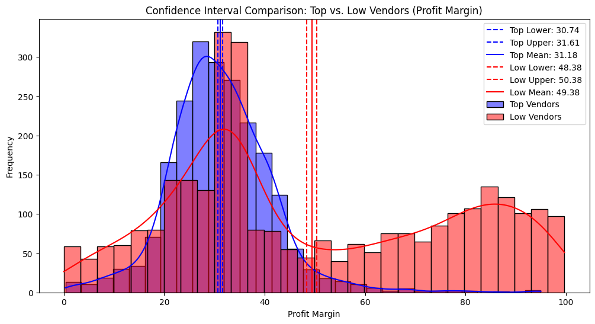

```python
# --- Confidence Intervals ---
top_mean, top_lower, top_upper = confidence_interval(top_vendors)
low_mean, low_lower, low_upper = confidence_interval(low_vendors)

print(f"Top Vendors 95% CI: ({top_lower:.2f}, {top_upper:.2f}), Mean: {top_mean:.2f}")
print(f"Low Vendors 95% CI: ({low_lower:.2f}, {low_upper:.2f}), Mean: {low_mean:.2f}")

plt.figure(figsize=(12, 6))

# --- Top Vendors Plot ---
sns.histplot(top_vendors, kde=True, bins=30, alpha=0.5, color="blue", label="Top Vendors")
plt.axvline(top_lower, color="blue", linestyle="--", label=f"Top Lower: {top_lower:.2f}")
plt.axvline(top_upper, color="blue", linestyle="--", label=f"Top Upper: {top_upper:.2f}")
plt.axvline(top_mean,  color="blue", linestyle="-",  label=f"Top Mean: {top_mean:.2f}")

# --- Low Vendors Plot ---
sns.histplot(low_vendors, kde=True, bins=30, alpha=0.5, color="red", label="Low Vendors")
plt.axvline(low_lower, color="red", linestyle="--", label=f"Low Lower: {low_lower:.2f}")
plt.axvline(low_upper, color="red", linestyle="--", label=f"Low Upper: {low_upper:.2f}")
plt.axvline(low_mean,  color="red", linestyle="-",  label=f"Low Mean: {low_mean:.2f}")

# --- Final Plot ---
plt.title("Confidence Interval Comparison: Top vs. Low Vendors (Profit Margin)")
plt.xlabel("Profit Margin")
plt.ylabel("Frequency")
plt.legend()
plt.show()
```

**H₀ (Null Hypothesis):**  
There is no significant difference in the mean profit margins of top-performing and low-performing vendors.

**H₁ (Alternative Hypothesis):**  
The mean profit margins of top-performing and low-performing vendors are significantly different.

```python
#
df.to_excel("VENDORPERFORMANCE.xlsx", index=False)
```